# Data Wrangling

### Student Name: [Michael Corrado]

```python
# Library to supress warnings or deprecation notes
import warnings
warnings.filterwarnings('ignore')

# Libraries to help with reading and manipulating data
import numpy as np
import pandas as pd

# Libraries to help with data visualization
import matplotlib.pyplot as plt
%matplotlib inline
import seaborn as sns
```

#### Step 1 – Programmatically download the required data for December 2019.

```python
url = 'https://www1.nyc.gov/site/tlc/about/tlc-trip-record-data.page' #provide the link to the data for December 2019


data = pd.read_csv('/Users/Michael/Python Anaconda/Machine_Learning_SHU/Data_Wrangling_3/yellow_tripdata_2019-12.csv') #load the data into a dataframe
```

```python
data.head()
```

|  | VendorID | tpep_pickup_datetime | tpep_dropoff_datetime | passenger_count | trip_distance | RatecodeID | store_and_fwd_flag | PULocationID | DOLocationID | payment_type | fare_amount | extra | mta_tax | tip_amount | tolls_amount | improvement_surcharge | total_amount | congestion_surcharge |
| --- | --- | --- | --- | --- | --- | --- | --- | --- | --- | --- | --- | --- | --- | --- | --- | --- | --- | --- |
| 0 | 1.0 | 2019-12-01 00:26:58 | 2019-12-01 00:41:45 | 1.0 | 4.2 | 1.0 | N | 142 | 116 | 2.0 | 14.5 | 3.0 | 0.5 | 0.0 | 0.0 | 0.3 | 18.3 | 2.5 |
| 1 | 1.0 | 2019-12-01 00:12:08 | 2019-12-01 00:12:14 | 1.0 | 0.0 | 1.0 | N | 145 | 145 | 2.0 | 2.5 | 0.5 | 0.5 | 0.0 | 0.0 | 0.3 | 3.8 | 0.0 |
| 2 | 1.0 | 2019-12-01 00:25:53 | 2019-12-01 00:26:04 | 1.0 | 0.0 | 1.0 | N | 145 | 145 | 2.0 | 2.5 | 0.5 | 0.5 | 0.0 | 0.0 | 0.3 | 3.8 | 0.0 |
| 3 | 1.0 | 2019-12-01 00:12:03 | 2019-12-01 00:33:19 | 2.0 | 9.4 | 1.0 | N | 138 | 25 | 1.0 | 28.5 | 0.5 | 0.5 | 10.0 | 0.0 | 0.3 | 39.8 | 0.0 |
| 4 | 1.0 | 2019-12-01 00:05:27 | 2019-12-01 00:16:32 | 2.0 | 1.6 | 1.0 | N | 161 | 237 | 2.0 | 9.0 | 3.0 | 0.5 | 0.0 | 0.0 | 0.3 | 12.8 | 2.5 |

```python
data.info()
```

```
<class 'pandas.core.frame.DataFrame'>
RangeIndex: 6896317 entries, 0 to 6896316
Data columns (total 18 columns):
 #   Column                 Dtype
---  ------                 -----
 0   VendorID               float64
 1   tpep_pickup_datetime   object
 2   tpep_dropoff_datetime  object
 3   passenger_count        float64
 4   trip_distance          float64
 5   RatecodeID             float64
 6   store_and_fwd_flag     object
 7   PULocationID           int64
 8   DOLocationID           int64
 9   payment_type           float64
 10  fare_amount            float64
 11  extra                  float64
 12  mta_tax                float64
 13  tip_amount             float64
 14  tolls_amount           float64
 15  improvement_surcharge  float64
 16  total_amount           float64
 17  congestion_surcharge   float64
dtypes: float64(13), int64(2), object(3)
memory usage: 947.1+ MB
```

#### Step 2 – Report the number of rows and columns in the data.

```python
#Print the number of rows and columns in data.
data.count()
```

```
VendorID                 6845299
tpep_pickup_datetime     6896317
tpep_dropoff_datetime    6896317
passenger_count          6845299
trip_distance            6896317
RatecodeID               6845299
store_and_fwd_flag       6845299
PULocationID             6896317
DOLocationID             6896317
payment_type             6845299
fare_amount              6896317
extra                    6896317
mta_tax                  6896317
tip_amount               6896317
tolls_amount             6896317
improvement_surcharge    6896317
total_amount             6896317
congestion_surcharge     6896317
dtype: int64
```

```python
data.shape
```

```
(6896317, 18)
```

#### Step 3 – Gather summary/descriptive statistics. State your initial observations (no more than 1 paragraph) and identify any inconsistencies.

HINT: you can use the **describe** function

```python
#display the summary statistics using the describe() function from the pandas dataframe
#state your observations or any inconsistencies that were detected in step 3
data.describe().T
```

|  | count | mean | std | min | 25% | 50% | 75% | max |
| --- | --- | --- | --- | --- | --- | --- | --- | --- |
| VendorID | 6845299.0 | 1.666457 | 0.471479 | 1.00 | 1.00 | 2.00 | 2.00 | 2.00 |
| passenger_count | 6845299.0 | 1.550877 | 1.174330 | 0.00 | 1.00 | 1.00 | 2.00 | 9.00 |
| trip_distance | 6896317.0 | 2.973421 | 16.431134 | -37264.53 | 0.96 | 1.60 | 3.03 | 19130.18 |
| RatecodeID | 6845299.0 | 1.065756 | 0.930987 | 1.00 | 1.00 | 1.00 | 1.00 | 99.00 |
| PULocationID | 6896317.0 | 163.652470 | 66.057584 | 1.00 | 125.00 | 162.00 | 233.00 | 265.00 |
| DOLocationID | 6896317.0 | 161.489222 | 70.337527 | 1.00 | 112.00 | 162.00 | 234.00 | 265.00 |
| payment_type | 6845299.0 | 1.298993 | 0.487940 | 1.00 | 1.00 | 1.00 | 2.00 | 5.00 |
| fare_amount | 6896317.0 | 13.590268 | 152.269222 | -1472.00 | 6.50 | 9.50 | 15.43 | 398468.38 |
| extra | 6896317.0 | 1.108518 | 1.259892 | -4.50 | 0.00 | 0.50 | 2.50 | 90.06 |
| mta_tax | 6896317.0 | 0.492415 | 0.072339 | -0.50 | 0.50 | 0.50 | 0.50 | 3.30 |
| tip_amount | 6896317.0 | 2.244620 | 2.875127 | -200.80 | 0.00 | 1.92 | 3.00 | 404.44 |
| tolls_amount | 6896317.0 | 0.388124 | 1.715502 | -40.50 | 0.00 | 0.00 | 0.00 | 612.66 |
| improvement_surcharge | 6896317.0 | 0.297986 | 0.033814 | -0.30 | 0.30 | 0.30 | 0.30 | 0.30 |
| total_amount | 6896317.0 | 19.641649 | 152.523581 | -1472.80 | 11.30 | 14.80 | 21.35 | 398471.20 |
| congestion_surcharge | 6896317.0 | 2.275278 | 0.735967 | -2.50 | 2.50 | 2.50 | 2.50 | 3.00 |

**Observations:**

- The describe function shows us that we have some missing data within a dataset. I further investigated this and calculated .73% of the information for the VendorID, passenger_count, RatecodeID, store_and_fwd_flag and payment type is missing.
- I also notice that the standard deviations are fairly large in fare_amount and total_amount. This indicates that there are most likely large outliers in this dataset.
- In the min column I see negative numbers, I personally do not know how this is possible and would would assume these were entered by mistake into the dataset

#### Step 4 – Examine the data for missing observations and duplicate records. Suggest what methods are appropriate to handle them.

```python
print(data.duplicated().sum())
```

```
0
```

```python
data.isna().sum().sum()
```

```
255090
```

```python
print(data.isnull().sum())
```

```
VendorID                 51018
tpep_pickup_datetime         0
tpep_dropoff_datetime        0
passenger_count          51018
trip_distance                0
RatecodeID               51018
store_and_fwd_flag       51018
PULocationID                 0
DOLocationID                 0
payment_type             51018
fare_amount                  0
extra                        0
mta_tax                      0
tip_amount                   0
tolls_amount                 0
improvement_surcharge        0
total_amount                 0
congestion_surcharge         0
dtype: int64
```

```python
data.isna().sum()/(len(data))*100
```

```
VendorID                 0.739786
tpep_pickup_datetime     0.000000
tpep_dropoff_datetime    0.000000
passenger_count          0.739786
trip_distance            0.000000
RatecodeID               0.739786
store_and_fwd_flag       0.739786
PULocationID             0.000000
DOLocationID             0.000000
payment_type             0.739786
fare_amount              0.000000
extra                    0.000000
mta_tax                  0.000000
tip_amount               0.000000
tolls_amount             0.000000
improvement_surcharge    0.000000
total_amount             0.000000
congestion_surcharge     0.000000
dtype: float64
```

```python
data = data.drop(['VendorID'], axis=1)
```

```python
data=data.dropna()
```

```python
data.shape
```

```
(6845299, 17)
```

**Observations:**

- Since the number of missing data was so minuscule I decided to remove all missing data. In my mind this was the best way to keep the integrity of the data.

#### Step 5 – Plot a histogram showing the distribution of the trip distance. Discuss your observations (no more than 1 paragraph).

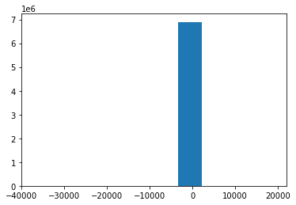

```python
plt.hist(data['trip_distance'])
```

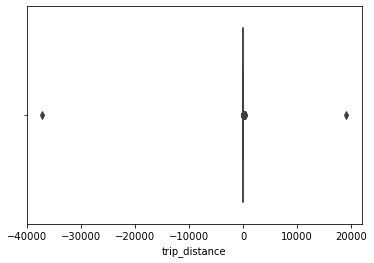

```python
sns.boxplot(x=data['trip_distance'])
```

**Observations:**

- The histogram is not the appropriate graph to use for this data set, I am unsure why the figure axis looks this way. I have tried many options to fix it. I think something with the data is not allowing us to read it correctly.
- The boxplot shows two major outliers that we will later remove.

#### Step 6 – Did you detect any outliers in step 5? If so, perform a suitable method to handle them?

```python
data = data[data['trip_distance'] < 10000]
```

```python
data = data[data['trip_distance'] > -10000]
```

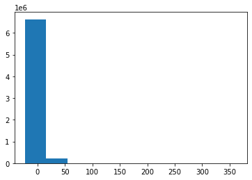

```python
plt.hist(data['trip_distance'])
```

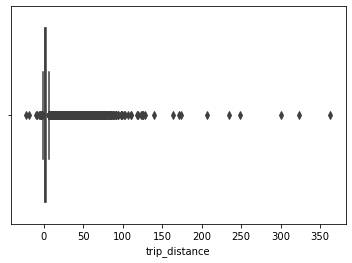

```python
sns.boxplot(x=data['trip_distance'])
```

**Observations:**

- After taking away the outliers we can see both the histogram and botox changed to show a better distribution of the data. This is an important lesson we can use for future work

#### Step 7 – Show the frequency of trips for each date. Do you see any interesting patterns or do you detect the need for additional data prep. rules.

```python
print(data['tpep_dropoff_datetime'].value_counts())
```

```
2019-12-29 00:00:00    85
2019-12-07 00:00:00    74
2019-12-22 00:00:00    73
2019-12-28 00:00:00    72
2019-12-14 00:00:00    68
                       ..
2019-12-19 06:40:12     1
2019-12-19 06:43:21     1
2019-12-19 06:27:17     1
2019-12-19 06:35:28     1
2019-12-31 00:56:00     1
Name: tpep_dropoff_datetime, Length: 2180419, dtype: int64
```

#### Step 8

- (a) Create a visualization that shows how people pay for their cab rides (e.g. credit card, cash, etc.). Can you say what is the most popular mode of payment?
- (b) Filter the data to only include customers who paid via credit card.

```python
data['payment_type'].value_counts(ascending=True)
```

```
5.0          1
4.0      20138
3.0      37089
2.0    1912099
1.0    4875971
Name: payment_type, dtype: int64
```

**Key**

- 1 = Credit card
- 2 = Cash
- 3 = No charge
- 4 = Dispute
- 5 = Unknown
- 6 = Voided trip

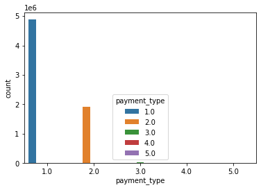

```python
sns.countplot(x='payment_type', hue='payment_type', data=data)
```

**Observations:**

- Most individuals paid by credit card, This was surprising to me but with the rise of technology and apps paying with a card has become extremely accessible.

#### Step 9 – Create a compelling visualization, based on your intuition, about the data and any useful insights on what factors contribute to cab driver's gratuity.

For example:

- Is there any correlation between the pickup/drop-off location and the gratuity?
- Does the trip distance or duration influence gratuity?

[figure not shown]

```python
plt.figure(figsize=(15, 10))
sns.heatmap(data.corr(), annot=True, fmt=".2f")
plt.show()
```

**Observations:**

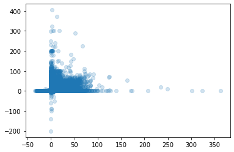

```python
plt.scatter(data['trip_distance'],data['tip_amount'], alpha=0.2, cmap='viridis')
```

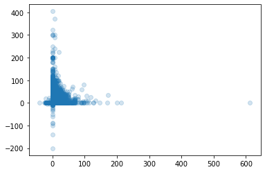

```python
plt.scatter(data['tolls_amount'],data['tip_amount'], alpha=0.2, cmap='viridis')
```

**Observations:**

- Above a weak correlation can be seen for both graphs